# Assignment01 VIS

Jessica Tang

9/16/2020

### Libraries

```r
library(ggplot2)
library(tidyverse)
library(tidycensus)
library(scales)
```

### Dataset

I am using the same data I am using for Quant.

```r
hh_rent_data <- get_pums(variables = c("SERIALNO",
                                     "TEN",
                                     "FS",
                                     "LNGI",
                                     "GRNTP",
                                     "HINCP",
                                     "GRPIP",
                                     "NP"),
                       state = "NY",
                       year = 2018,
                       survey = "acs1",
                       recode = TRUE) %>%
  mutate(HC = GRNTP,
         HCPIP = GRPIP,
         Burdened = case_when(
           HCPIP > 30 ~ "Yes",
           TRUE ~ "No")) %>%
  filter(TEN_label == "Rented") %>%
  select(SERIALNO,
         TEN_label,
         FS_label,
         LNGI_label,
         HC,
         HINCP,
         HCPIP,
         Burdened,
         NP)


hh_own_data <- get_pums(variables = c("SERIALNO",
                                      "TEN",
                                      "FS",
                                      "LNGI",
                                      "SMOCP",
                                      "HINCP",
                                      "OCPIP",
                                      "NP"),
                        state = "NY",
                        year = 2018,
                        survey = "acs1",
                        recode = TRUE) %>%

  mutate(HC = SMOCP,
         HCPIP = OCPIP,
         Burdened = case_when(OCPIP > 30 ~ "Yes",
                              TRUE ~ "No")) %>%

  filter(!TEN_label == "Rented",
         !TEN_label == "Occupied without payment of rent",
         !TEN_label == "N/A (GQ/vacant)") %>%

  select(SERIALNO,
         TEN_label,
         FS_label,
         LNGI_label,
         HC,
         HINCP,
         HCPIP,
         Burdened,
         NP)


all_hh <- rbind(hh_rent_data,
                hh_own_data)
```

### Plot 1

- Compares Household Income (continuous) and Rent (continuous). Indicates whether or not someone is Rent Burdened, but I don’t know if this says much since theoretically it’s just Income/Rent or rise/run…?
- I had to cap a few of my Plots at income < 100,000, otherwise the axes would just get really squished. I also removed any income < 0
- Looks like more people are rent-burdened than not
- Note to self: How to create an axes break so that I can show millionaires on the same plot, without squishing axes?

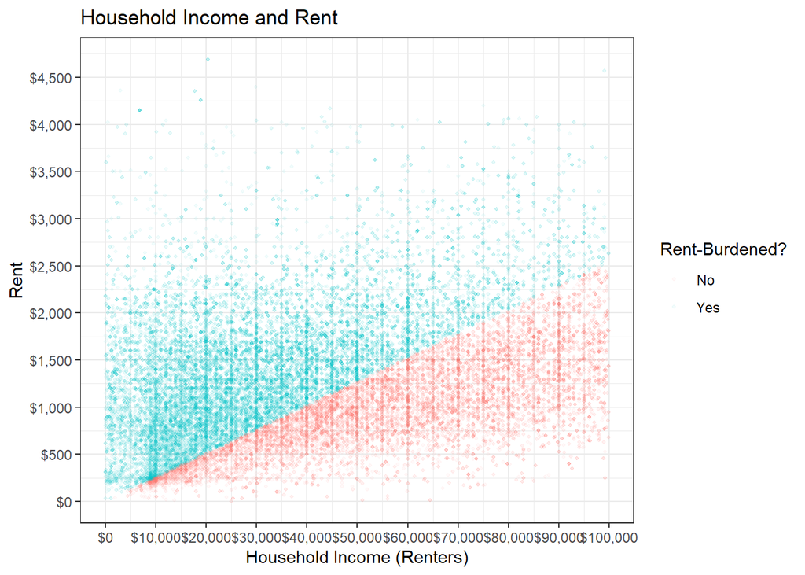

```r
ggplot(filter(all_hh,
              TEN_label == "Rented",
              HINCP < 100000,
              HINCP > 0),

       aes(x = HINCP,
           y = HC,
           color = Burdened)) +

  ggtitle("Household Income and Rent") +

  geom_point(size = 0.75,
             alpha = 0.05) +

  scale_x_continuous(name = "Household Income (Renters)",
                     breaks = seq(0, 100000, by = 10000),
                     labels = dollar) +

  scale_y_continuous(name = "Rent",
                     breaks = seq(0, 15000, by = 500),
                     labels = dollar) +

  scale_color_discrete(name = "Rent-Burdened?") +

  theme(axis.text.x = element_text(angle = 45)) +

  theme_bw()
```

### Plot 2

- Compares Number of People in Household (discrete) and Tenure (discrete) with Household Income (continuous)
- Looks like households that own free and clear (pink) have fewer people than households with mortgage or loan (blue)
- Note to self: How to override alpha in the legend so that the legend dots are not so transparent?

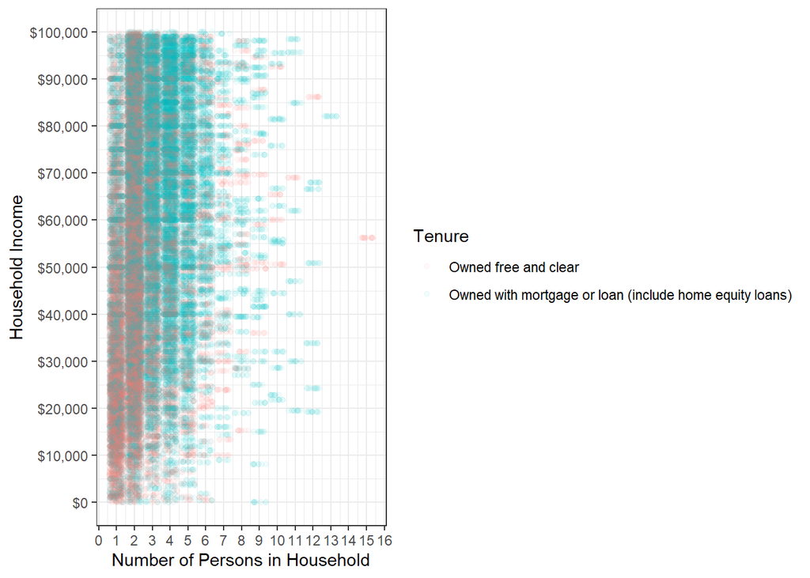

```r
ggplot(filter(all_hh,
              HINCP < 100000,
              HINCP > 0,
              !TEN_label == "Rented"),

       aes(x = NP,
           y = HINCP,
           color = TEN_label)) +

  geom_point(alpha = 0.05,
             position = "jitter") +

  scale_x_continuous(name = "Number of Persons in Household",
                     breaks = seq(0, 20, by = 1)) +

  scale_y_continuous(name = "Household Income",
                     breaks = seq(0, 100000, by = 10000),
                     labels = dollar) +

  scale_color_discrete(name = "Tenure") +

  theme_bw()
```

### Plot 3

- This is a plot I made **after** the discussion on Tuesday. It is similar to Plot 2, and an improvement as well I think. Plus, I figured out how to increase the plot size dimensions.

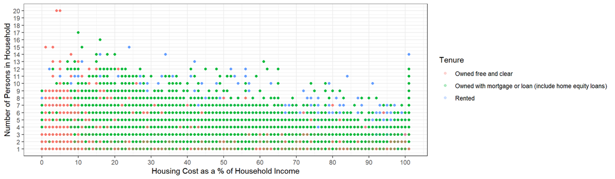

```r
ggplot (all_hh,

        aes(x = HCPIP,
            y = NP,
            color = TEN_label)) +

  geom_point(alpha = 0.3) +

  scale_x_continuous(name = "Housing Cost as a % of Household Income",
                     breaks = seq(0, 100, 10)) +

  scale_y_continuous(name = "Number of Persons in Household",
                   breaks = seq(0, 20, 1)) +

  scale_color_discrete(name = "Tenure") +

  theme_bw()
```

### Plot 4

- Still compares Number of People in Household (discrete) and Tenure (discrete) with Household Income (continuous), just on a polar coordinate system.
- Note to self: Still need to look into how to read this. Chris Dsida said the y-axis scale corresponds with distance from center?

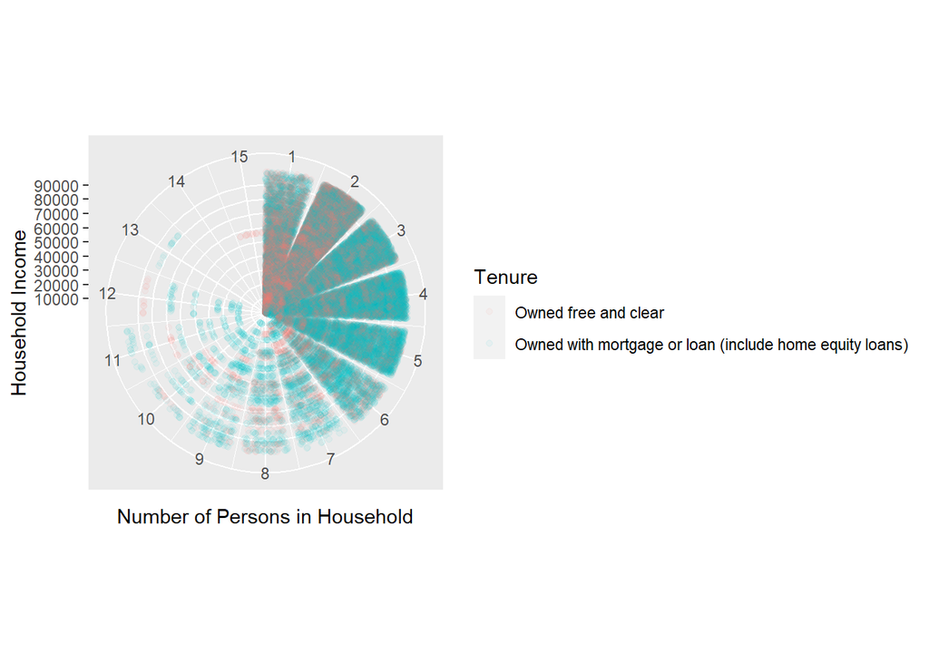

```r
ggplot(filter(all_hh,
              HINCP < 100000,
              HINCP > 0,
              !TEN_label == "Rented"),

       aes(x = NP,
           y = HINCP,
           color = TEN_label)) +

  geom_point(alpha = 0.05,
             position = "jitter") +

  scale_x_continuous(name = "Number of Persons in Household",
                     breaks = seq(0, 20, by = 1)) +

  scale_y_continuous(name = "Household Income",
                     breaks = seq(0, 100000, by = 10000)) +

  scale_color_discrete(name = "Tenure") +

  coord_polar(theta = "x") +

  theme_gray()
```

### Plot 5

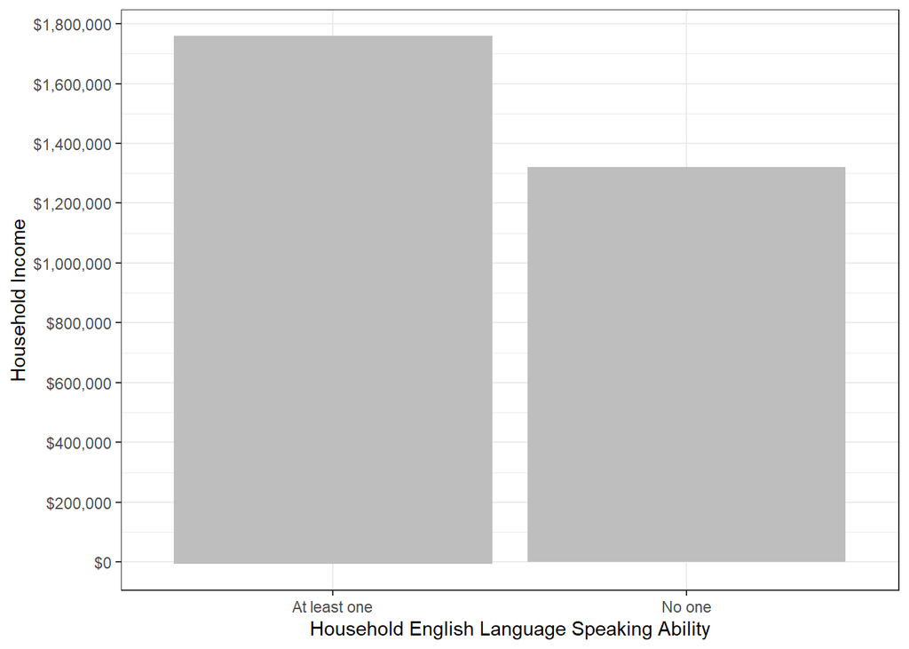

```r
ggplot(all_hh,

       aes(x = LNGI_label,
           y = HINCP)) +

  geom_bar(stat = "identity",
           position = "dodge",
           fill = "gray") +

  scale_x_discrete(name = "Household English Language Speaking Ability",
                   labels = c("At least one",
                              "No one")) +

  scale_y_continuous(name = "Household Income",
                     breaks = seq(0, 2000000, by = 200000),
                     labels = dollar) +

  scale_fill_discrete(name = "Tenure") +

  theme_bw()
```

### Plot 6

- Plots frequency/count (continuous) of Household Income (continuous)
- I wonder what the spike is between people who make 600,000 and people who make 700,000
- Tested out the `coord_flip()` function

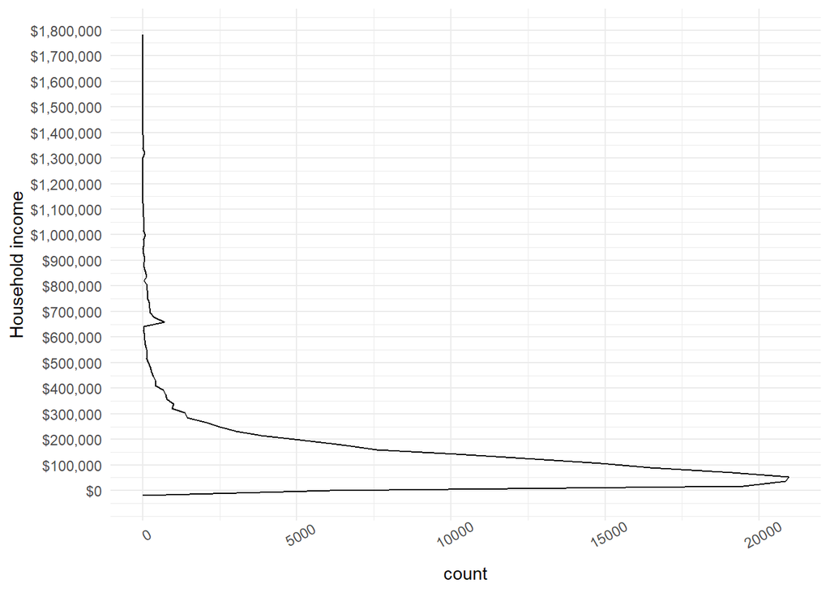

```r
ggplot(all_hh,

       aes(x = HINCP)) +

  geom_freqpoly(bins = 100) +

  scale_x_continuous (name = "Household income",
                      breaks = seq(0, 2000000, 100000),
                      labels = dollar) +

  coord_flip() +

  theme_minimal() +

  theme(axis.text.x = element_text(angle = 30))
```

### Plot 7a

- Comparing type of Tenure (categorical) with Food Stamps (categorical).
- For some reason I had a really hard time conceptualizing this plot and the relationship between the 2 variables, until I saw Jonathan Lee’s work.
- Note to self: Axis will not tilt x degrees if you put `theme(axis.text.x = element_text(angle = 30))` BEFORE `theme_minimal`. Have to put it AFTER.

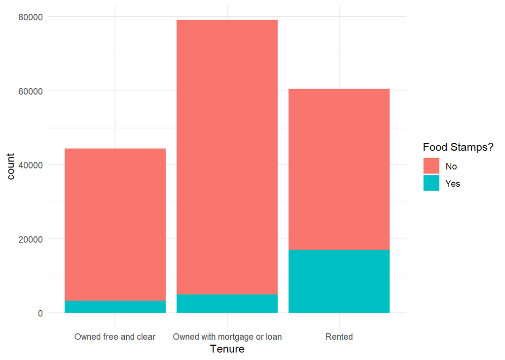

```r
ggplot (all_hh,

        aes(x = TEN_label,
            fill = FS_label)) +

  geom_bar() +

  scale_x_discrete(name = "Tenure",
                   labels = c("Owned free and clear",
                              "Owned with mortgage or loan",
                              "Rented")) +

  scale_fill_discrete(name = "Food Stamps?") +

  theme_minimal()
```

### Plot 7b

- Comparing type of Tenure (categorical) with Food Stamps (categorical). All I did here was change the position to “dodge”.

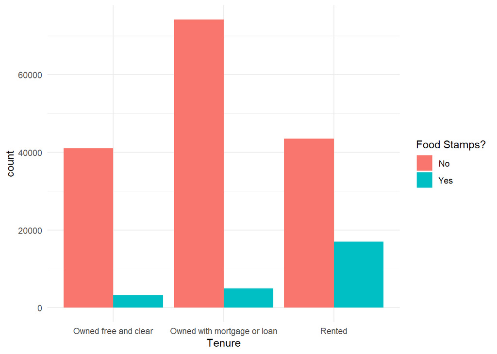

```r
ggplot (all_hh,

        aes(x = TEN_label,
            fill = FS_label)) +

  geom_bar(position = "dodge") +

  scale_x_discrete(name = "Tenure",
                   labels = c("Owned free and clear",
                              "Owned with mortgage or loan",
                              "Rented")) +

  scale_fill_discrete(name = "Food Stamps?") +

  theme_minimal()
```

### Plot 8

- Comparing Food Stamps (categorical) to Housing Cost as % of Income (HCPIP) in renter-occupied households.
- Plot is darkest between 10 and 40 percent for both “No” and “Yes” because most people’s rent falls within this percentage range as a percent of income.
- Would be interesting to get more data on employment status of people who pay more than 30% of their income on rent and who are NOT on Food Stamps. Looking between the “No” and “Yes” columns, looks like almost half who are rent-burdened do take Food Stamps and half do not.

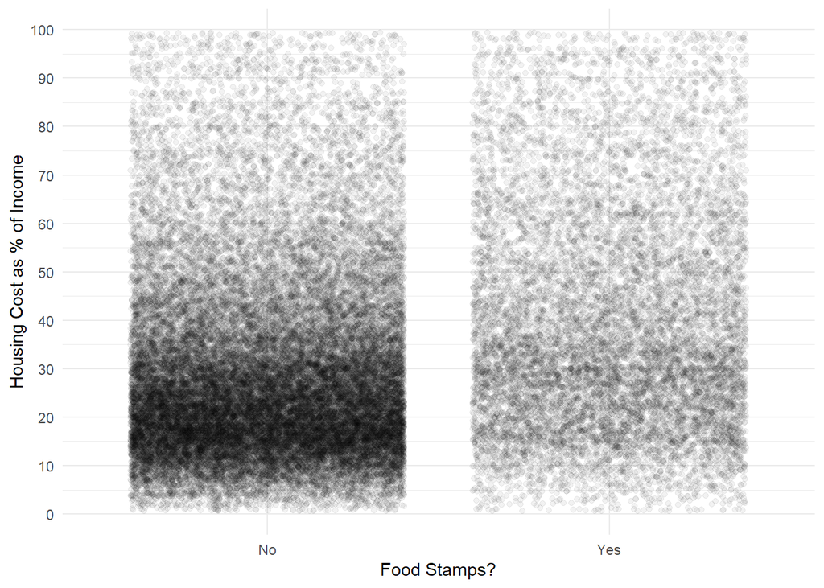

```r
ggplot (filter(all_hh,
               HCPIP < 100,
               HCPIP > 0,
               TEN_label == "Rented"),

        aes(x = FS_label,
            y = HCPIP)) +

  geom_point(alpha = 0.05,
             position = "jitter") +

  scale_x_discrete(name = "Food Stamps?") +

  scale_y_continuous(name = "Housing Cost as % of Income",
                     breaks = seq(0, 100, by = 10)) +

  theme_minimal()
```

### Plot 9

- I tried layering 3 violin plots – one for each type of Tenure: Rented, Owned free and clear, and Owned with mortgage or loan. I hope my labeling is correct… but, assuming it is, this shows:
  - More Households are less likely to be on Food Stamps than are likely.
  - I am sure something else can be said about the relationship between Tenure (categorical), Food Stamps (categorical), and Housing Cost % (continuous).
- Note to self: How much less likely are these Households to be on Food Stamps? Can I calculate this by comparing the areas of the violins??

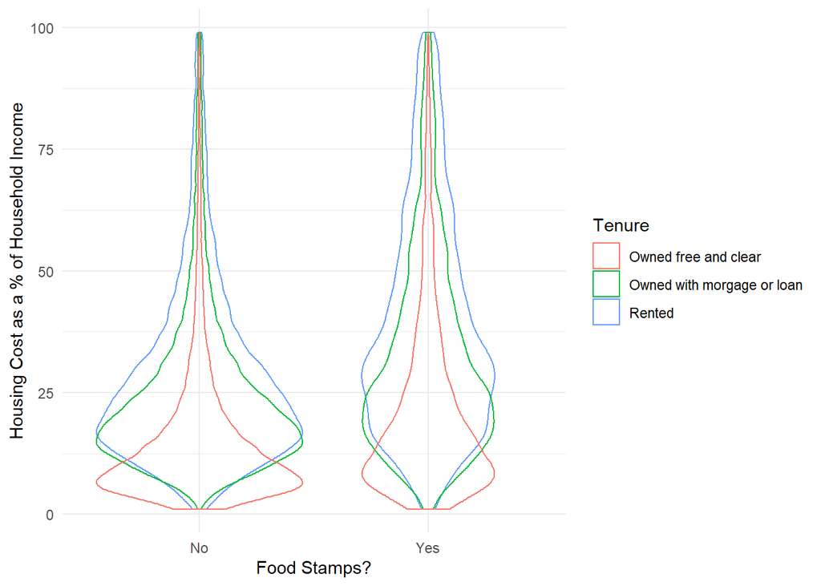

```r
ggplot ( filter(all_hh,
                HCPIP < 100,
                HCPIP > 0,
                TEN_label == "Rented"),

        aes(x = FS_label,
            y = HCPIP,
            color = "Rented")) +

  # Bottom violin plot (blue)

  geom_violin(alpha = 0) +

  scale_x_discrete(name = "Food Stamps?") +

  scale_y_continuous(name = "Housing Cost as a % of Household Income") +

  scale_color_discrete(name = "Tenure") +

  # Middle layer violin plot (green)

  geom_violin( data = filter(all_hh,
                            HCPIP < 100,
                            HCPIP > 0,
                            TEN_label == "Owned with mortgage or loan (include home equity loans)"),

               aes(x = FS_label,
                  y = HCPIP,
                  color = "Owned with morgage or loan"),

               alpha = 0) +

  # Bottom layer violin plot (red)

  geom_violin( data = filter(all_hh,
                            HCPIP < 100,
                            HCPIP > 0,
                            TEN_label == "Owned free and clear"),

               aes(x = FS_label,
                   y = HCPIP,
                   color = "Owned free and clear"),

               alpha = 0) +

  theme_minimal()
```

### Plot 10

- I started to get confused about what I have plotted and what I haven’t – which combinations I have exhausted vs. not. So I came up with a question:

  Out of households that rent that make more than 60k, how many are burdened and how many of them have 0 people who speak English?
  - I am trying to overlay 2 histograms, but to no avail. I would like the Burdened/Not as another categorical variable that gets plotted, and want to highlight the overlap. Is this possible? Following the overlay structure that I used in `geom_violin` above did not work here.

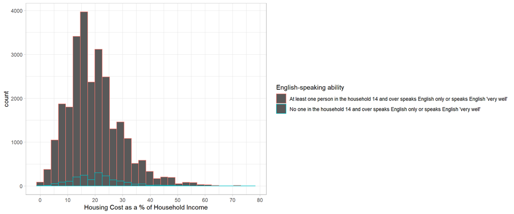

```r
ggplot (filter(all_hh,
               HINCP > 60000,
               TEN_label == "Rented"),

        aes(x = HCPIP,
            color = LNGI_label)) +

geom_histogram() +

  scale_x_continuous(name = "Housing Cost as a % of Household Income",
                     breaks = seq(0, 100, 10)) +

  scale_color_discrete(name = "English-speaking ability") +



  theme_light()
```

### Issues/Questions

**Last Note to Self:** I am getting confused which dot plots do what… something to keep in mind.